# Sliding Window Based Anomaly Detection

Algorithm of this sliding window based anomaly detection on time series data:

  CI = mean +(-) (im * sd) / sqrt(windowSize)

  where mean is mean, sd is standard deviation of sliding window. im is a hyper parameter that is used to tune success of model.
- If next value out of window is outside of confidence interval, mark as anomolous, if not non-anomolous.

Define hyperParameters :

```r
windowSizeStart = 17
windowSizeEnd = 17

intervalMultiplier = 25 # it is used to adjust model success
```

Define set to store experiment results, that will be used to analyze statistical behaviour of model.

```r
resultSet = data.frame(matrix(ncol = 6, nrow = 0))
colnames(resultSet) <- c("windowSize", "IntervalMultiplier", "tp", "fp", "tn", "fn")
```

Load data which is merged and standardized version of Yahoo A1Benchmark dataset including 67 files.

```r
setwd("C:/Users/sametyazak/Desktop/ynwa/bau/2017 - Thesis/code/r/")
completeData = read.csv(file="..\\..\\data\\workspace\\real_full_standard.csv", header=TRUE, sep=",")
completeData = cbind(completeData, predicted_value = 0, conf_low = 0, conf_high = 0, predicted_anomaly = 0, calculation_value = completeData$value)
```

Define helper functions:

```r
getConfidenceInterval <- function(studentTIndex, windowSize, windowRecords) {
  standardDeviation = sd(windowRecords$calculation_value)
  mn = mean(windowRecords$calculation_value)
  diff = (intervalMultiplier*standardDeviation)/sqrt(windowSize)

  return (data.frame(mn-diff,mn+diff))
}
```

Calculate confidence interval and model results.

```r
print("Prediction Start:")
```

```
## [1] "Prediction Start:"
```

```r
print(date())
```

```
## [1] "Wed Dec 27 17:12:45 2017"
```

```r
for (windowSize in windowSizeStart:windowSizeEnd) {
  windowWeight = seq(1, windowSize, length=windowSize)
  print(paste0("windowSize:", windowSize))

  tp = 0; tn = 0; fp = 0; fn = 0

  startIndex = (windowSize+1)
  endIndex = dim(completeData)[1]

  windowEndIndex = windowSize
  windowStartIndex = 1

  windowRecords = completeData[completeData$timestamp >= windowStartIndex & completeData$timestamp <= windowEndIndex,];

    for (i in startIndex:endIndex) {
      completeData[i,"predicted_value"] = 0
      completeData[i,"conf_low"] = 0
      completeData[i,"conf_high"] = 0
      completeData[i,"predicted_anomaly"] = 0

      if (i != startIndex) {
        windowRecords = rbind(windowRecords[windowRecords$timestamp > (i-windowSize-1),], completeData[i-1,])
      }

      windowForecast = getConfidenceInterval(0, windowSize, windowRecords);

      completeData[i,"predicted_value"] = completeData[i,"value"]
      completeData[i,"conf_low"] = windowForecast[1,1]
      completeData[i,"conf_high"] = windowForecast[1,2]

      predictedAnomaly = if (completeData[i,"value"] <= completeData[i,"conf_high"] & completeData[i,"value"] >= completeData[i,"conf_low"]) 0 else 1

      completeData[i,"predicted_anomaly"] = predictedAnomaly

      if (completeData[i,"is_anomaly"] == 1) {
        #completeData[i,"predicted_value"] = completeData[i,"value"]
        lowerDistance = abs(completeData[i,"value"] - completeData[i,"conf_low"])
        upperDistance = abs(completeData[i,"value"] - completeData[i,"conf_high"])
        completeData[i,"calculation_value"] = (completeData[i,"conf_high"] + completeData[i,"conf_low"])/2
      }

      if (completeData[i,"is_anomaly"] == 1 & predictedAnomaly == 1) {
        tp = tp + 1;
      } else if (completeData[i,"is_anomaly"] == 1 & predictedAnomaly == 0) {
        fn = fn + 1
      } else if (completeData[i,"is_anomaly"] == 0 & predictedAnomaly == 1) {
        fp = fp + 1
      } else if (completeData[i,"is_anomaly"] == 0 & predictedAnomaly == 0) {
        tn = tn + 1
      }

    }

    resultSet = rbind(resultSet, data.frame(windowSize, intervalMultiplier, tp, fp, tn, fn))
    print(paste0("tp:", tp, ", fp:", fp, ", tn:", tn, ", fn:", fn))
}
```

```
## [1] "windowSize:17"
## [1] "tp:1358, fp:319, tn:92861, fn:311"
```

```r
print("Prediction End:")
```

```
## [1] "Prediction End:"
```

```r
print(date())
```

```
## [1] "Wed Dec 27 18:03:45 2017"
```

Print result set:

```r
resultSet
```

|  | windowSize | intervalMultiplier | tp | fp | tn | fn |
| --- | --- | --- | --- | --- | --- | --- |
| 1 | 17 | 25 | 1358 | 319 | 92861 | 311 |

|  | windowSize <int> | intervalMultiplier <dbl> | tp <dbl> | fp <dbl> | tn <dbl> | fn <dbl> |
| --- | --- | --- | --- | --- | --- | --- |
| 1 | 17 | 25 | 1358 | 319 | 92861 | 311 |

1 row

```r
fullResultSet = read.csv(file="window_20171227.csv", header=TRUE, sep=",")

fullResultSet = cbind(fullResultSet,
                      sensitivity = fullResultSet$tp / (fullResultSet$tp + fullResultSet$fn),
                      positivePredictive = fullResultSet$tp / (fullResultSet$tp + fullResultSet$fp),
                      specificity = fullResultSet$tn / (fullResultSet$tn + fullResultSet$fp),
                      negativePredictive = fullResultSet$tn / (fullResultSet$tn + fullResultSet$fn))

fullResultSet
```

| X | windowSize | intervalMultiplier | tp | fp | tn | fn | sensitivity | positivePredictive | specificity | negativePredictive |
| --- | --- | --- | --- | --- | --- | --- | --- | --- | --- | --- |
| 1 | 3 | 20 | 1471 | 2333 | 90861 | 198 | 0.8813661 | 0.3866982 | 0.9749662 | 0.9978256 |
| 2 | 4 | 20 | 1457 | 1407 | 91786 | 212 | 0.8729778 | 0.5087291 | 0.9849023 | 0.9976956 |
| 3 | 5 | 20 | 1443 | 1090 | 92102 | 226 | 0.8645896 | 0.5696802 | 0.9883037 | 0.9975522 |
| 4 | 6 | 20 | 1434 | 909 | 92282 | 235 | 0.8591971 | 0.6120359 | 0.9902458 | 0.9974599 |
| 5 | 7 | 20 | 1441 | 801 | 92389 | 228 | 0.8633913 | 0.6427297 | 0.9914047 | 0.9975382 |
| 6 | 8 | 20 | 1435 | 691 | 92498 | 234 | 0.8597963 | 0.6749765 | 0.9925850 | 0.9974766 |
| 7 | 9 | 20 | 1427 | 678 | 92510 | 242 | 0.8550030 | 0.6779097 | 0.9927244 | 0.9973909 |
| 8 | 10 | 20 | 1433 | 664 | 92523 | 236 | 0.8585980 | 0.6833572 | 0.9928745 | 0.9974558 |
| 9 | 11 | 20 | 1422 | 664 | 92522 | 247 | 0.8520072 | 0.6816874 | 0.9928745 | 0.9973375 |
| 10 | 12 | 20 | 1425 | 682 | 92503 | 244 | 0.8538047 | 0.6763170 | 0.9926812 | 0.9973692 |

[output cut: 44 more lines]

| X <int> | windowSize <int> | intervalMultiplier <int> | tp <int> | fp <int> | tn <int> | fn <int> | sensitivity <dbl> | positivePredictive <dbl> | specificity <dbl> |  |
| --- | --- | --- | --- | --- | --- | --- | --- | --- | --- | --- |
| 1 | 3 | 20 | 1471 | 2333 | 90861 | 198 | 0.8813661 | 0.3866982 | 0.9749662 |  |
| 2 | 4 | 20 | 1457 | 1407 | 91786 | 212 | 0.8729778 | 0.5087291 | 0.9849023 |  |
| 3 | 5 | 20 | 1443 | 1090 | 92102 | 226 | 0.8645896 | 0.5696802 | 0.9883037 |  |
| 4 | 6 | 20 | 1434 | 909 | 92282 | 235 | 0.8591971 | 0.6120359 | 0.9902458 |  |
| 5 | 7 | 20 | 1441 | 801 | 92389 | 228 | 0.8633913 | 0.6427297 | 0.9914047 |  |
| 6 | 8 | 20 | 1435 | 691 | 92498 | 234 | 0.8597963 | 0.6749765 | 0.9925850 |  |
| 7 | 9 | 20 | 1427 | 678 | 92510 | 242 | 0.8550030 | 0.6779097 | 0.9927244 |  |
| 8 | 10 | 20 | 1433 | 664 | 92523 | 236 | 0.8585980 | 0.6833572 | 0.9928745 |  |
| 9 | 11 | 20 | 1422 | 664 | 92522 | 247 | 0.8520072 | 0.6816874 | 0.9928745 |  |
| 10 | 12 | 20 | 1425 | 682 | 92503 | 244 | 0.8538047 | 0.6763170 | 0.9926812 |  |

Plot sample parts of dataset:

Green: True Positive (correctly identified anomaly) Records Yellow: False Negative (anomalies identified as non-anomolous) Records red: False Positive (non-anomolous records identified as anomaly)

First 1500 records (1-1500):

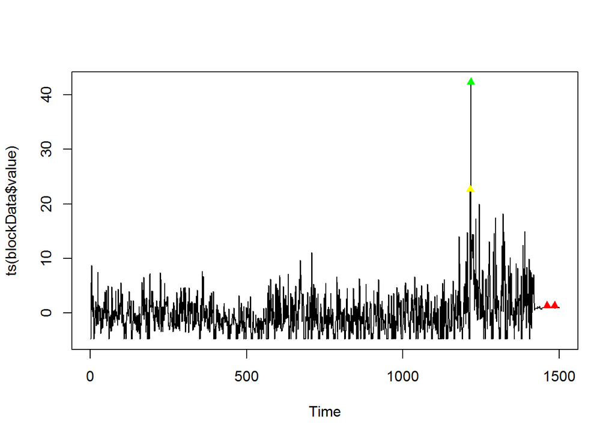

```r
blockData = completeData[completeData$timestamp <= 1500,]
tpAnomalies = blockData[blockData$is_anomaly == 1 & blockData$predicted_anomaly == 1,]
fnAnomalies = blockData[blockData$is_anomaly == 1 & blockData$predicted_anomaly == 0,]
fpAnomalies = blockData[blockData$is_anomaly == 0 & blockData$predicted_anomaly == 1,]

plot.ts(ts(blockData$value))
points(data.frame(tpAnomalies$timestamp, tpAnomalies$value), col="green", pch=17)
points(data.frame(fnAnomalies$timestamp, fnAnomalies$value), col="yellow", pch=17)
points(data.frame(fpAnomalies$timestamp , fpAnomalies$value), col="red", pch=17)
```

Second 1500 records (1500-3000):

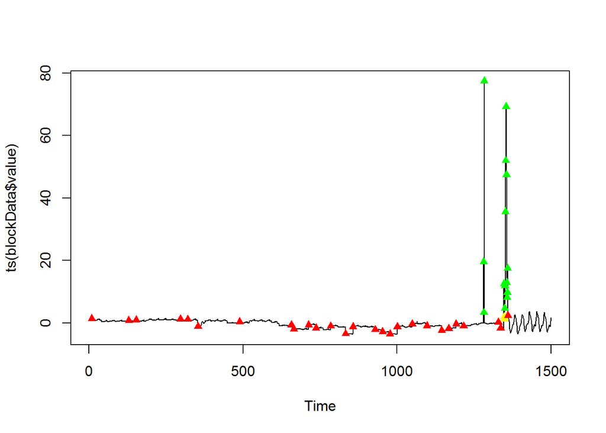

```r
blockData = completeData[completeData$timestamp > 1500 & completeData$timestamp <= 3000,]
tpAnomalies = blockData[blockData$is_anomaly == 1 & blockData$predicted_anomaly == 1,]
fnAnomalies = blockData[blockData$is_anomaly == 1 & blockData$predicted_anomaly == 0,]
fpAnomalies = blockData[blockData$is_anomaly == 0 & blockData$predicted_anomaly == 1,]

plot.ts(ts(blockData$value))
points(data.frame(tpAnomalies$timestamp - 1500, tpAnomalies$value), col="green", pch=17)
points(data.frame(fnAnomalies$timestamp - 1500, fnAnomalies$value), col="yellow", pch=17)
points(data.frame(fpAnomalies$timestamp - 1500, fpAnomalies$value), col="red", pch=17)
```

Third 1500 records (3000-4500):

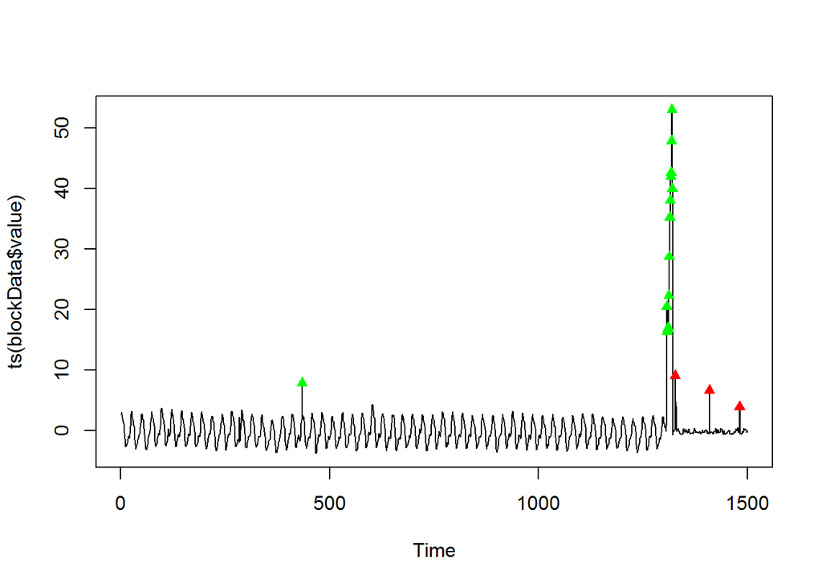

```r
blockData = completeData[completeData$timestamp <= 4500 & completeData$timestamp > 3000,]
tpAnomalies = blockData[blockData$is_anomaly == 1 & blockData$predicted_anomaly == 1,]
fnAnomalies = blockData[blockData$is_anomaly == 1 & blockData$predicted_anomaly == 0,]
fpAnomalies = blockData[blockData$is_anomaly == 0 & blockData$predicted_anomaly == 1,]

plot.ts(ts(blockData$value))
points(data.frame(tpAnomalies$timestamp - 3000, tpAnomalies$value), col="green", pch=17)
points(data.frame(fnAnomalies$timestamp - 3000, fnAnomalies$value), col="yellow", pch=17)
points(data.frame(fpAnomalies$timestamp - 3000, fpAnomalies$value), col="red", pch=17)
```